# p8105_hw3_zy2440

yangzhixin

2020年10月8日

# Problem 1

```r
library(dplyr)
library(p8105.datasets)
data("instacart")
aisles <- instacart %>%
  group_by(aisle) %>%
  summarize(n_number=n())
```

There are 134 aisles in total, the most items are ordered from aisle "fresh vegetables".

The plot:

```r
library(tidyverse)
```

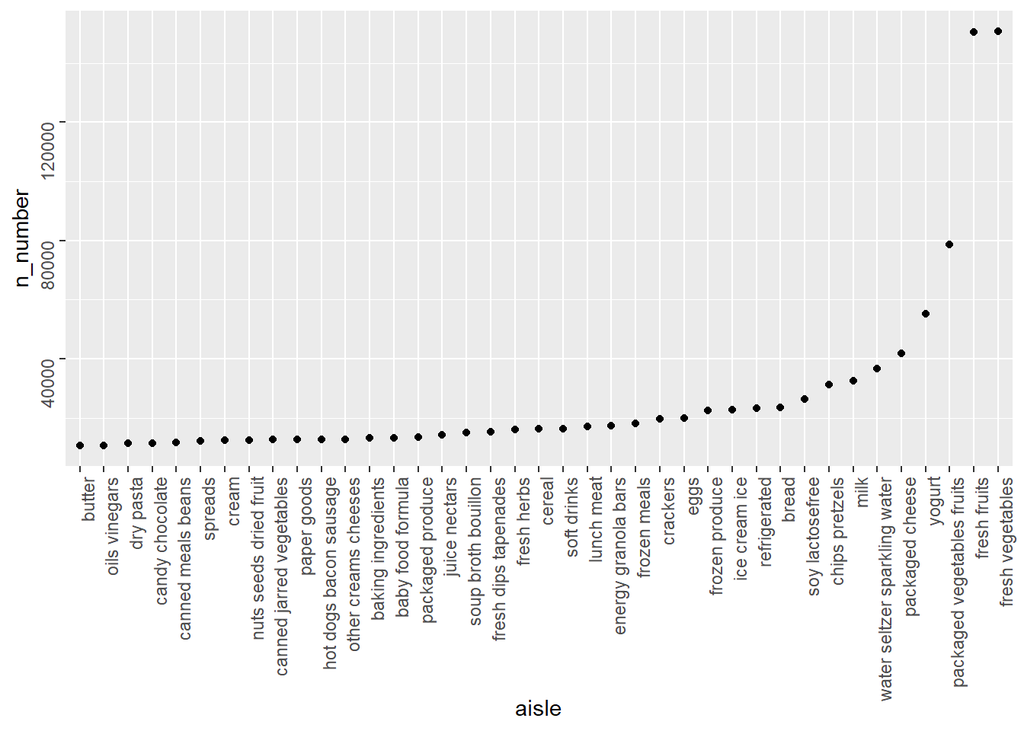

```r
aisles %>%
  filter(n_number>10000) %>%
  mutate(aisle=fct_reorder(aisle,n_number)) %>%
  ggplot(aes(x=aisle,y=n_number)) +
  geom_point() +
  theme(axis.text = element_text(angle = 90, vjust = 0.5, hjust = 1))
```

The table:

```r
instacart %>%
  filter(aisle %in% c("baking ingredients","dog food care","packaged vegetables friuts "))%>%
  group_by(aisle) %>%
  count(product_name) %>%
  mutate(rank = min_rank(desc(n))) %>%
  filter(rank < 4) %>%
  arrange(aisle,rank) %>%
  knitr::kable()
```

| aisle | product_name | n | rank |
| --- | --- | --- | --- |
| baking ingredients | Light Brown Sugar | 499 | 1 |
| baking ingredients | Pure Baking Soda | 387 | 2 |
| baking ingredients | Cane Sugar | 336 | 3 |
| dog food care | Snack Sticks Chicken & Rice Recipe Dog Treats | 30 | 1 |
| dog food care | Organix Chicken & Brown Rice Recipe | 28 | 2 |
| dog food care | Small Dog Biscuits | 26 | 3 |

Pink Lady Apples and Coffee Ice Cream:

```r
instacart %>%
  filter(product_name %in% c("Pink Lady Apples","Coffee Ice Cream")) %>%
  group_by(product_name,order_dow) %>%
  summarize(mean_hour = mean(order_hour_of_day)) %>%
  pivot_wider(names_from = order_dow, values_from = mean_hour)
```

```
## # A tibble: 2 x 8
## # Groups:   product_name [2]
##   product_name       `0`   `1`   `2`   `3`   `4`   `5`   `6`
##   <chr>            <dbl> <dbl> <dbl> <dbl> <dbl> <dbl> <dbl>
## 1 Coffee Ice Cream  13.8  14.3  15.4  15.3  15.2  12.3  13.8
## 2 Pink Lady Apples  13.4  11.4  11.7  14.2  11.6  12.8  11.9
```

# Problem 2

## 2.1 Wrangle the data.

```r
accel_df <- read_csv("accel_data.csv") %>%
  pivot_longer(cols=starts_with("activity"), names_to="activity_minute", values_to="activity_count") %>%
  mutate(day_type=ifelse(day %in% c("Monday","Tuesday","Wednesday","Thursday","Friday"),"weekday","weekend"))
```

Summary: For the dataset wrangled, the variables are week, day_id, day, activity_minute, activity_count, day_type, 50400 observations are included.

## 2.2 Traditional analyses of accelerometer data

```r
accel_day <- accel_df %>%
  group_by(day_id) %>%
  summarize(day_count = sum(activity_count)) %>%
  merge(distinct(accel_df,day_id,.keep_all = TRUE)[c(1,2,3,6)])
```

# 2.3 Plot

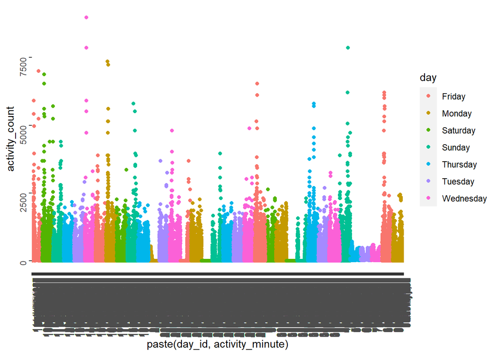

```r
accel_df %>%
  ggplot(aes(x=paste(day_id,activity_minute),y=activity_count)) +
  geom_point(aes(color = day)) +
  theme(axis.text = element_text(angle = 90, vjust = 0.5, hjust = 1))
```

# Problem 3

## 3.1 Data cleaning

```r
data("ny_noaa")
noaa <- ny_noaa %>%
  separate(date,into=c('year','month','day')) %>%
  mutate(tmax = as.numeric(tmax),tmin = as.numeric(tmin))
snow_sort <- names(sort(table(noaa$snow),decreasing = TRUE))
```

## Summary

The dataset includes variables id, date, prcp, snow, snwd, tmax, tmin and there are 2595176 observations in total. For perception, there are 5.62% values missing, and for snow, there are 14.69% values missing.

After cleaning and sorting of the data, we can see the most observed values are 0, 25, 13

## 3.2 Plot temperature in January and July

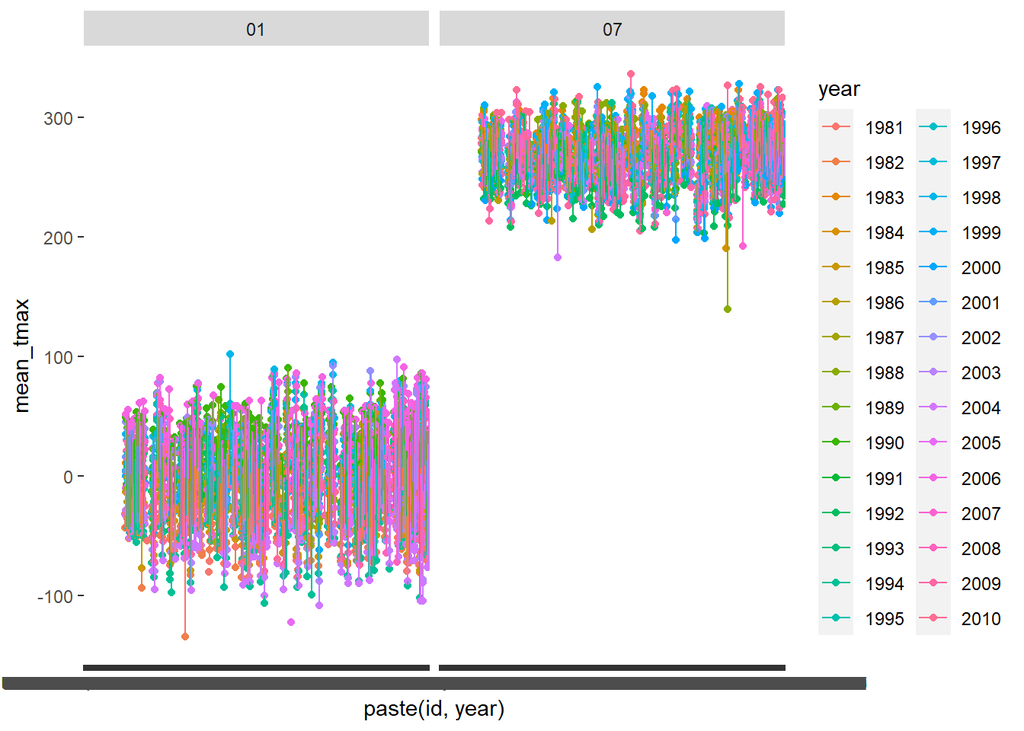

```r
noaa %>%
  group_by(id,year,month) %>%
  summarize(mean_tmax=mean(tmax,na.rm = TRUE)) %>%
  filter(xor(month =="01",month=="07")) %>%
  ggplot(aes(x=paste(id,year),y=mean_tmax,color=year,group = id)) +
  geom_point() +
  geom_path() +
  facet_grid(.~month)
```

It can be seen from this plot that the average tempreture in July is usually higher than in January. There are a few outliers in each month but they do not compromise the structure we observe.

## 3.3

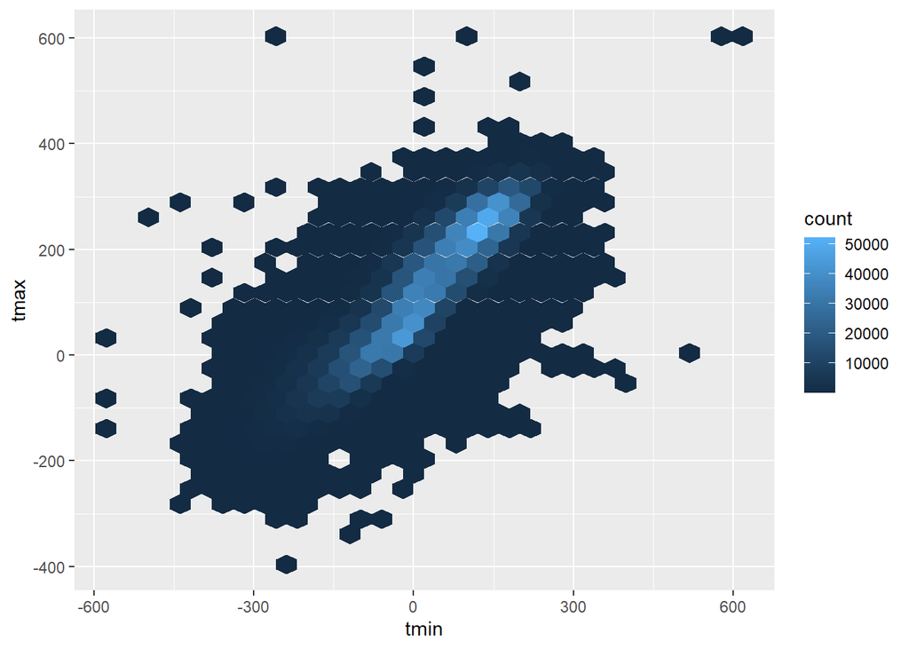

```r
library(hexbin)
noaa %>%
  ggplot(aes(x=tmin,y=tmax)) +
  geom_hex()
```

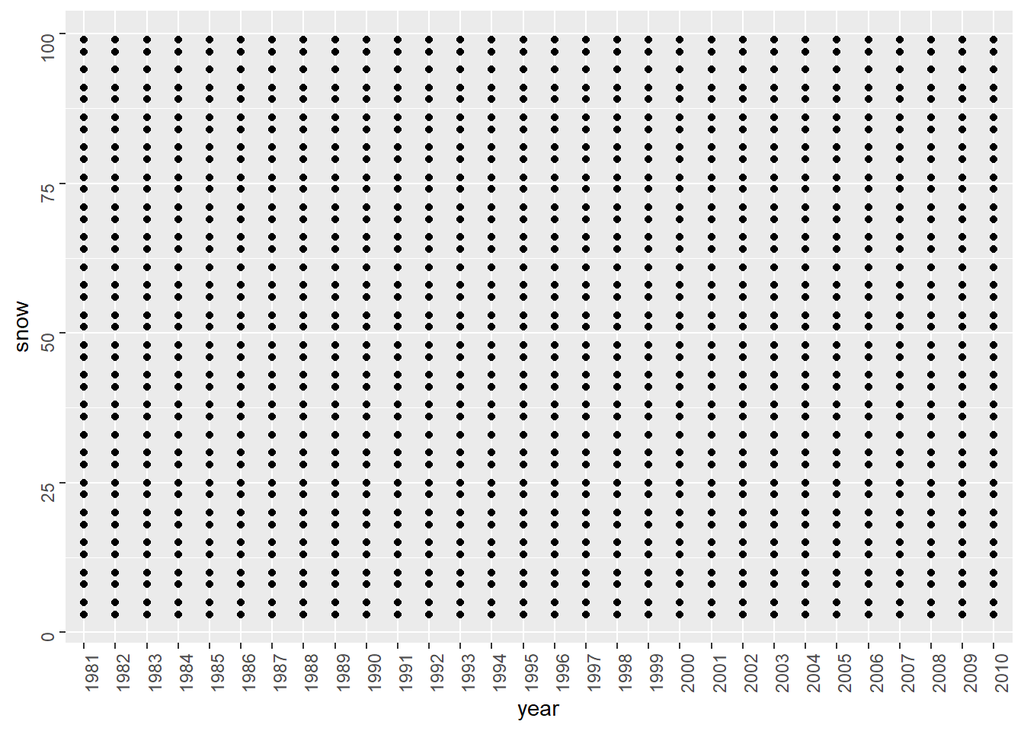

```r
noaa %>%
  filter(snow>0 & snow<100) %>%
  ggplot(aes(x=year,y=snow)) +
  geom_point() +
  theme(axis.text = element_text(angle = 90, vjust = 0.5, hjust = 1))
```